# DNA_RNA_Project

MM,TG,AR,AA,GT,VP,EG,AL

2025-06-05

# Analysis of different levels of methylation between disease and control samples

## 1. Load Raw Data with minfi and create an object called RGset storing the RGChannelSet object:

```r
# Install libraries for methylation analysis
# if (!require("BiocManager", quietly = TRUE))
#     install.packages("BiocManager")
# BiocManager::install("minfi")
# BiocManager::install("minfiData")
```

```r
# Load required libraries for methylation analysis
suppressPackageStartupMessages({
library(minfi)
library(minfiData)
library(qqman)
library(gplots)
})

setwd(".")
baseDir <- ("../Input_Data")
SampleSheet <- read.csv("../Input_Data/SampleSheet_Report_II.csv", header =
                          T)
targets <- read.metharray.sheet(baseDir) # read sample sheet metadata
```

```
## [read.metharray.sheet] Found the following CSV files:
```

```
## [1] "../Input_Data/SampleSheet_Report_II.csv"
```

```r
# Load raw methylation data into RGChannelSet object and save the raw data object
RGset <- read.metharray.exp(targets = targets)
save(RGset, file = "RGset.RData")
```

## 2. Create the dataframes Red and Green to store the red and green fluorescences respectively.

```r
# Extract raw red and green fluorescence intensities into two dataframes
Red <- data.frame(getRed(RGset))
dim(Red)
```

```
## [1] 622399      8
```

```r
head(Red)
```

```
##          GSM5319592_200121140049_R01C02 GSM5319603_3999356129_R02C02
## 10600313                            322                          159
## 10600322                            361                          231
## 10600328                           1522                          469
## 10600336                           4916                         3034
## 10600345                            875                          252
## 10600353                            596                          205
##          GSM5319604_3999547012_R02C01 GSM5319607_3999547012_R03C02
## 10600313                          303                          419
## 10600322                          553                          919
## 10600328                         1682                         2301
## 10600336                         9117                        13823
## 10600345                         1168                         1326
## 10600353                          556                          860
##          GSM5319609_3999547016_R02C01 GSM5319613_3999547017_R02C01
## 10600313                          294                          346
## 10600322                          127                          731
## 10600328                         1163                         1085
## 10600336                         2664                        10864
## 10600345                          457                         1828
## 10600353                          477                          444
##          GSM5319615_3999547017_R04C01 GSM5319616_3999547017_R06C01
## 10600313                          523                          491
## 10600322                          943                          574
## 10600328                         1708                         1250
## 10600336                        12023                        11925
## 10600345                         2138                          899
## 10600353                          632                          478
```

```r
Green <- data.frame(getGreen(RGset))
dim(Green)
```

```
## [1] 622399      8
```

```r
head(Green)
```

```
##          GSM5319592_200121140049_R01C02 GSM5319603_3999356129_R02C02
## 10600313                            134                           53
## 10600322                           3109                         1160
## 10600328                           1764                          669
## 10600336                            566                          336
## 10600345                           1558                          277
## 10600353                           1903                          476
##          GSM5319604_3999547012_R02C01 GSM5319607_3999547012_R03C02
## 10600313                          124                          198
## 10600322                         3546                         5033
## 10600328                         2246                         2497
## 10600336                          873                         1279
## 10600345                         1147                         1555
## 10600353                         1967                         1994
##          GSM5319609_3999547016_R02C01 GSM5319613_3999547017_R02C01
## 10600313                          133                          157
## 10600322                          694                         4135
## 10600328                         1820                         1229
## 10600336                          275                          804
## 10600345                          558                         2103
## 10600353                         1632                         1595
##          GSM5319615_3999547017_R04C01 GSM5319616_3999547017_R06C01
## 10600313                          146                          146
## 10600322                         4955                         3743
## 10600328                         1827                         1645
## 10600336                         1012                          986
## 10600345                         2053                         1323
## 10600353                         2719                         1889
```

## 3. Extract the fluorescence values for the address 39802405, which corresponds to a type II probe.

```r
load("../Illumina450Manifest_clean.RData")

# Retrieve probe type for the address 39802405

probe_type <- Illumina450Manifest_clean[Illumina450Manifest_clean$AddressA_ID == "39802405", "Infinium_Design_Type"]

print(paste0("The probe type is: " , probe_type))
```

```
## [1] "The probe type is: II"
```

```r
# Extract red and green intensities for this address
Red[rownames(Red) == "39802405", ]
```

```
##          GSM5319592_200121140049_R01C02 GSM5319603_3999356129_R02C02
## 39802405                           1843                          877
##          GSM5319604_3999547012_R02C01 GSM5319607_3999547012_R03C02
## 39802405                         2779                         3807
##          GSM5319609_3999547016_R02C01 GSM5319613_3999547017_R02C01
## 39802405                         1248                         4105
##          GSM5319615_3999547017_R04C01 GSM5319616_3999547017_R06C01
## 39802405                         5057                         5272
```

```r
Green[rownames(Green) == "39802405", ]
```

```
##          GSM5319592_200121140049_R01C02 GSM5319603_3999356129_R02C02
## 39802405                           3523                         1345
##          GSM5319604_3999547012_R02C01 GSM5319607_3999547012_R03C02
## 39802405                          434                         5099
##          GSM5319609_3999547016_R02C01 GSM5319613_3999547017_R02C01
## 39802405                          331                          452
##          GSM5319615_3999547017_R04C01 GSM5319616_3999547017_R06C01
## 39802405                          600                          596
```

## 4. Create the object MSet.raw:

```r
# Generate raw methylation set object from RGset and save the preprocessed object
MSet.raw <- preprocessRaw(RGset)
save(MSet.raw, file = "MSet_raw.RData")
```

## 5. Perform the following quality checks: QCplot, intensity of negative controls using minfi, detection pValues.

```r
# generate qc plot
qc <- getQC(MSet.raw)
qc
```

```
## DataFrame with 8 rows and 2 columns
##                                     mMed      uMed
##                                <numeric> <numeric>
## GSM5319592_200121140049_R01C02  10.26327   9.76321
## GSM5319603_3999356129_R02C02     8.62205   8.82018
## GSM5319604_3999547012_R02C01    10.35094  10.23721
## GSM5319607_3999547012_R03C02    10.79360  10.90313
## GSM5319609_3999547016_R02C01     8.82655   8.83289
## GSM5319613_3999547017_R02C01    10.83684  10.69523
## GSM5319615_3999547017_R04C01    11.15038  11.04644
## GSM5319616_3999547017_R06C01    10.27845  10.33316
```

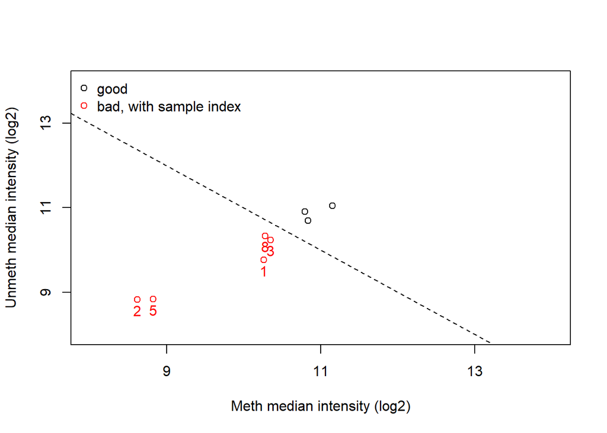

```r
plotQC(qc)
```

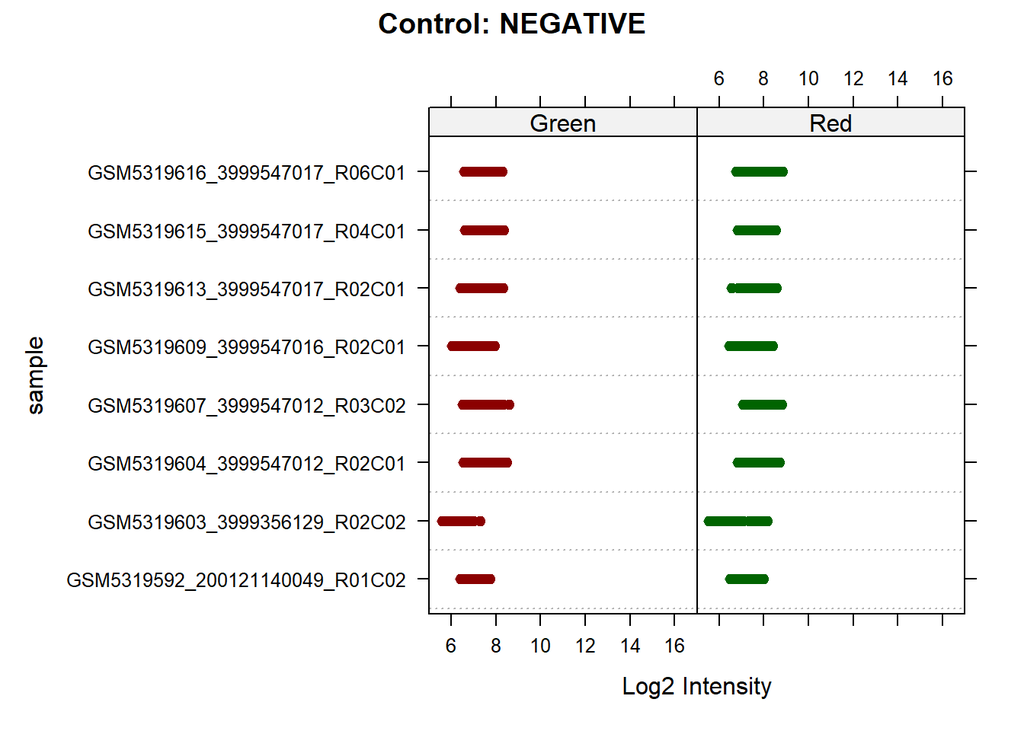

```r
# Visualize intensity of negative control probes
controlStripPlot(RGset, controls = "NEGATIVE")
```

```r
# detection p-values for each probe
detP <- detectionP(RGset)
save(detP, file = "detP.RData")

load("detP.RData")

failed <- detP > 0.01    # Flag probes with p > 0.01 as TRUE or FALSE
nfailed <- colSums(failed) # Count the number of failed probes per sample
nfailed
```

```
## GSM5319592_200121140049_R01C02   GSM5319603_3999356129_R02C02
##                            303                            563
##   GSM5319604_3999547012_R02C01   GSM5319607_3999547012_R03C02
##                           1702                            611
##   GSM5319609_3999547016_R02C01   GSM5319613_3999547017_R02C01
##                           4555                            573
##   GSM5319615_3999547017_R04C01   GSM5319616_3999547017_R06C01
##                            467                            994
```

```r
head(failed)
```

```
##            GSM5319592_200121140049_R01C02 GSM5319603_3999356129_R02C02
## cg00050873                          FALSE                        FALSE
## cg00212031                          FALSE                        FALSE
## cg00213748                          FALSE                        FALSE
## cg00214611                          FALSE                        FALSE
## cg00455876                          FALSE                        FALSE
## cg01707559                          FALSE                        FALSE
##            GSM5319604_3999547012_R02C01 GSM5319607_3999547012_R03C02
## cg00050873                         TRUE                        FALSE
## cg00212031                         TRUE                        FALSE
## cg00213748                         TRUE                        FALSE
## cg00214611                         TRUE                        FALSE
## cg00455876                        FALSE                        FALSE
## cg01707559                        FALSE                        FALSE
##            GSM5319609_3999547016_R02C01 GSM5319613_3999547017_R02C01
## cg00050873                        FALSE                         TRUE
## cg00212031                        FALSE                        FALSE
## cg00213748                         TRUE                         TRUE
## cg00214611                         TRUE                         TRUE
## cg00455876                        FALSE                        FALSE
## cg01707559                        FALSE                        FALSE
##            GSM5319615_3999547017_R04C01 GSM5319616_3999547017_R06C01
## cg00050873                         TRUE                        FALSE
## cg00212031                         TRUE                         TRUE
## cg00213748                         TRUE                         TRUE
## cg00214611                         TRUE                         TRUE
## cg00455876                        FALSE                        FALSE
## cg01707559                        FALSE                        FALSE
```

```r
dim(failed)
```

```
## [1] 485512      8
```

```r
table(failed)
```

```
## failed
##   FALSE    TRUE
## 3874328    9768
```

## 6. Calculate raw beta and M values and plot the densities of mean methylation values, dividing the samples in WT and MUT.

```r
MSet.raw
```

```
## class: MethylSet
## dim: 485512 8
## metadata(0):
## assays(2): Meth Unmeth
## rownames(485512): cg00050873 cg00212031 ... ch.22.47579720R
##   ch.22.48274842R
## rowData names(0):
## colnames(8): GSM5319592_200121140049_R01C02
##   GSM5319603_3999356129_R02C02 ... GSM5319615_3999547017_R04C01
##   GSM5319616_3999547017_R06C01
## colData names(7): SampleID Sex ... Basename filenames
## Annotation
##   array: IlluminaHumanMethylation450k
##   annotation: ilmn12.hg19
## Preprocessing
##   Method: Raw (no normalization or bg correction)
##   minfi version: 1.54.1
##   Manifest version: 0.4.0
```

```r
# Calculate beta values and convert to dataframe
beta <- getBeta(MSet.raw)
beta_df <- data.frame(beta)

# Split the dataframe in WT (ctrl) and MUT (dis) samples for the beta values
df_ctrl <- beta_df[, c(
  "GSM5319592_200121140049_R01C02",
  "GSM5319607_3999547012_R03C02",
  "GSM5319615_3999547017_R04C01",
  "GSM5319616_3999547017_R06C01"
)]
head(df_ctrl)
```

```
##            GSM5319592_200121140049_R01C02 GSM5319607_3999547012_R03C02
## cg00050873                     0.93364780                   0.93726011
## cg00212031                     0.12357955                   0.05748638
## cg00213748                     0.80153846                   0.79600000
## cg00214611                     0.09612817                   0.06747475
## cg00455876                     0.73064289                   0.79484979
## cg01707559                     0.12267218                   0.05405405
##            GSM5319615_3999547017_R04C01 GSM5319616_3999547017_R06C01
## cg00050873                    0.6075697                    0.6316411
## cg00212031                    0.4135021                    0.4558304
## cg00213748                    0.4945946                    0.5161905
## cg00214611                    0.6016771                    0.4931507
## cg00455876                    0.3516896                    0.2846238
## cg01707559                    0.3304416                    0.3521289
```

```r
dim(df_ctrl)
```

```
## [1] 485512      4
```

```r
df_dis <- beta_df[, !names(beta_df) %in% c(
  "GSM5319592_200121140049_R01C02",
  "GSM5319607_3999547012_R03C02",
  "GSM5319615_3999547017_R04C01",
  "GSM5319616_3999547017_R06C01"
)]
dim(df_dis)
```

```
## [1] 485512      4
```

```r
head(df_dis)
```

```
##            GSM5319603_3999356129_R02C02 GSM5319604_3999547012_R02C01
## cg00050873                   0.88015897                    0.6303940
## cg00212031                   0.14744802                    0.4436090
## cg00213748                   0.79831933                    0.4548944
## cg00214611                   0.09731114                    0.4304636
## cg00455876                   0.60161409                    0.2426729
## cg01707559                   0.13912232                    0.2847222
##            GSM5319609_3999547016_R02C01 GSM5319613_3999547017_R02C01
## cg00050873                    0.6656299                    0.4894958
## cg00212031                    0.3770492                    0.4256506
## cg00213748                    0.5703125                    0.4123711
## cg00214611                    0.4604905                    0.6588542
## cg00455876                    0.2680608                    0.2503840
## cg01707559                    0.3046407                    0.3928171
```

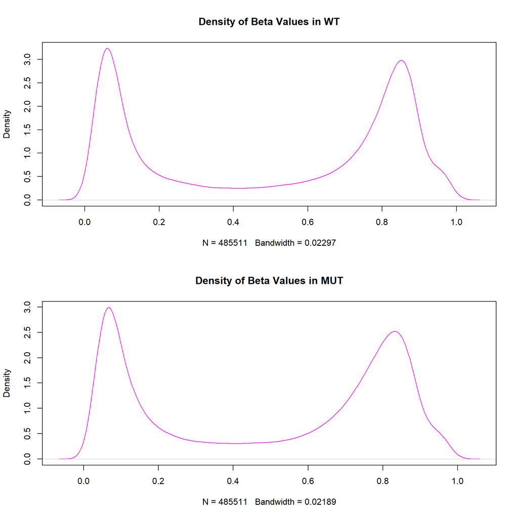

```r
# Compute mean beta values for WT and MUT groups
mean_beta_ctrl <- apply(df_ctrl, 1, mean, na.rm = T)
mean_beta_ctrl <- na.omit(mean_beta_ctrl)
d_mean_beta_ctrl <- density(mean_beta_ctrl)
mean_beta_dis <- apply(df_dis, 1, mean, na.rm = T)
mean_beta_dis <- na.omit(mean_beta_dis)
d_mean_beta_dis <- density(mean_beta_dis)

# Plot density of beta values
par(mfrow = c(2, 1))
plot(d_mean_beta_ctrl, main = "Density of Beta Values in WT", col = "magenta")
plot(d_mean_beta_dis, main = "Density of Beta Values in MUT", col = "magenta")
```

```r
# Calculate M values
M_df <- data.frame(getM(MSet.raw))

# Split the dataframe in WT (ctrl) and MUT (dis) samples for the M values
df_M_ctrl <- M_df[, c(
  "GSM5319592_200121140049_R01C02",
  "GSM5319607_3999547012_R03C02",
  "GSM5319615_3999547017_R04C01",
  "GSM5319616_3999547017_R06C01"
)]

df_M_dis <- M_df[, !names(M_df) %in% c(
  "GSM5319592_200121140049_R01C02",
  "GSM5319607_3999547012_R03C02",
  "GSM5319615_3999547017_R04C01",
  "GSM5319616_3999547017_R06C01"
)]

# Compute density for mean M values
mean_M_ctrl <- apply(df_M_ctrl, 1, mean, na.rm = T)
mean_M_ctrl <- na.omit(mean_M_ctrl)
d_mean_M_ctrl <- density(mean_M_ctrl)

mean_M_dis <- apply(df_M_dis, 1, mean, na.rm = T)
mean_M_dis <- na.omit(mean_M_dis)
d_mean_M_dis <- density(mean_M_dis)
```